# Lab #1 - Python Essentials

While Python programming is not the core focus of this course, software is an essential component of any machine learning project.

The goal of this lab is to provide a brief overview of Python concepts, syntax, and semantics that are relevant to machine learning applications. In particular, we'll cover topics related to data handling, preparation, and visualization in this lab.

The lab is written under the assumption that you're using the [Anaconda distribution](https://www.anaconda.com/products/distribution), an open source Python distribution that assists in package and environment management.

### Part 1 - Libraries

Most functions we'll use in this course are contained in collections of pre-built code known as *libraries*. Within Python libraries are *modules*, or bundles of related functions.

If you are using the Anaconda distribution, the code below will import two different libraries, [pandas](https://pandas.pydata.org/docs/user_guide/index.html) and [numpy](https://numpy.org/doc/stable/user/), that each contain functions for data handling and manipulation.

The code also assigns an *alias* to each library (ie: `pd` and `np`), which will reduce the amount of characters/typing needed to reference functions contained in these libraries.

```python
import pandas as pd
import numpy as np
```

The code below imports the `pyplot` module from the `matplotlib` graphics library using the alias `plt`. As you'll soon see, the `.` operator has a variety of uses, one of which is to reference modules within a library.

```python
import matplotlib.pyplot as plt
```

*Note*: If you are working outside of the Anaconda distribution you may need to install these libraries manually. [This guide](https://data-flair.training/blogs/install-pandas-on-windows/) provides a set of instructions for Windows, [This page](https://www.geeksforgeeks.org/how-to-install-python-pandas-on-macos/) provides a few different installation options on Mac.

### Part 2 - Basic Data Types

To effectively utilize functions contained in libraries, we'll need to understand a few common data types and how to interact with them. For our purposes, there are 4 basic types of interest (note that technically there are *many* more types):

1. Integers (ie: `5`)
2. Floats (ie: `5.0`)
3. Strings (ie: `'five'` or `'5'`)
4. Booleans (ie: `True` or `False`)

For some functions, integers and floats can be used interchangeably. While for others, integers are expected as respresentations of distinct categorical outcomes.

If necessary, variable types can be *converted* using a conversion function:

```python
## x contains the string '4'
x = '4'
type(x)
```

```
str
```

```python
## Convert x from str to float
new_x = float(x)
print(new_x)
type(new_x)
```

```
4.0
```

```
float
```

Other useful conversion functions are `int()` and `bool()`.

Be aware that `bool()` will convert anything other than zero to `True`:

```python
## Three different boolean conversions
print(bool(1.0), bool(-2), bool(0.0))
```

```
True True False
```

#### Storing data

There are wide variety of ways to store data in Python, but most of what we'll do will focus on three of them:

1. lists (base Python)
2. `numpy` arrays
3. `pandas` DataFrames

Lists are the simplest of these structures:

```python
## Simple list
my_list1 = [1,5,3,9]

## Lists within a list
my_list2 = [[1,3,5], [2,4,6]]
```

In the example above, `my_list2` is a list that contains two lists within it.

We can access these lists using indices:

```python
## The first list within `my_list2`
my_list2[0]
```

```
[1, 3, 5]
```

Note that Python indices begin at 0, so `my_list2[0]` returns the first item stored in `my_list2`, which is the list `[1,3,5]`.

Now suppose want the first 2 elements of `my_list1`:

```python
my_list1[:2]
```

```
[1, 5]
```

Recognize that the element in position `2` *is not included*, thus `:2` returns the elements in positions 0 and 1 (the list `[1,5]`). Also note that the syntax `0:2` yields the same result as `:2`.

Next, suppose we want to extract the integer `3` from `my_list2` (where it is the second element in the first list):

```python
my_list2[0][1]
```

```
3
```

This code first extracted the item in position 0 of `my_list2` (the list `[1,3,5]`), then it extracted the element in position 1 of the resulting list (the value `3`).

#### Question #1

- Create a list containing the strings 'one', 'two', 'three', 'four'. Write code that confirms the type of this list, then use indices to print the list's last two elements.

### Part 3 - Numpy Arrays

In our previous example, `my_list2[0][1]` gave us to access the integer `3`; unfortunately, the command `my_list2[0,1]` will not achieve the same result:

```python
my_list2[0,1]
```

```
---------------------------------------------------------------------------
TypeError                                 Traceback (most recent call last)
~\AppData\Local\Temp\ipykernel_15364\3441573747.py in <module>
----> 1 my_list2[0,1]

TypeError: list indices must be integers or slices, not tuple
```

This shortcoming helps motivate our next data structure, `numpy` arrays:

```python
my_array2 = np.array(my_list2)
my_array2[0,1]
```

```
3
```

While lists and arrays might seem similar, and some functions can handle either inputs, it is important to recognize that arrays belong to the `numpy` package, while lists exist within base Python. In future labs, I'll frequently use the term "array" without an explicit reference to the `numpy` library.

`numpy` arrays can be viewed as special case of lists with a few additional constraints that convey a number of benefits:

1. Arrays allow mathematical operations (vectorized addition/multiplication, and matrix algebra)
2. Arrays allow easier slicing across multiple dimensions
3. Arrays use substantially less memory to store the same data

Below is an example demonstrating the first advantage. Notice what happens when we try to add two lists:

```python
# For lists, + will concantenate
print(my_list1 + my_list1)

## For arrays, + works as intended (vectorized addition)
my_array1 = np.array(my_list1)
print(my_array1 + my_array1)
```

```
[1, 5, 3, 9, 1, 5, 3, 9]
[ 2 10  6 18]
```

`numpy` arrays are also our first opportunity to learn about two important aspects of Python objects:

1. **Attributes** - which can be viewed as the characteristics of an object
2. **Methods** - which can be viewed as the operations/actions of an object

Attributes are called using the syntax `my_object.attribute_name`, while methods are called uisng the syntax `my_object.method_name()`

For example, `numpy` arrays have a `shape` attribute and a `flatten()` method:

```python
## The shape attribute describes the array's dimensions
my_array2.shape
```

```
(2, 3)
```

```python
## The flatten method reshapes an n-dimensional array into a 1-dimensional array
my_array2.flatten()
```

```
array([1, 3, 5, 2, 4, 6])
```

A complete list of attributes and methods for n-dimensional `numpy` arrays can be [found here](https://numpy.org/doc/stable/reference/generated/numpy.ndarray.html).

#### Question #2

- Convert the list you created in Question #1 into a `numpy` array. Then use the `reshape()` method to organize it such that it contains two rows and two columns. Print the resulting object's `shape` attribute to verify your manipulations worked as intended. *Hint*: Use the numpy reference guide linked above to learn more about `reshape()`.

To conclude our introduction to arrays, one last thing to know is that the term `axis` refers one of an array's dimensions.

It's common for data to be organized into rows (observations/examples) and columns (variables/features). For such data, the `0` is the index of the row axis, and `1` is the index of the column axis.

Other types of data, such as colored images, are typically stored in higher dimensional arrays. For example, a single [RGB image](https://en.wikipedia.org/wiki/RGB_color_model) might be stored in an n by m by 3 array (where n and m are pixel dimensions, and 3 is the number of color channels).

### Part 4 - Pandas DataFrames

Now we're ready to look at some actual data. For this we'll use the `read_csv()` function in the `pandas` library to read a .csv file from the web (recall that we gave the alias `pd` to `pandas`):

```python
ic = pd.read_csv("https://remiller1450.github.io/data/IowaCityHomeSales.csv")
ic.shape
```

```
(777, 19)
```

The dataset stored in `ic` was scraped from the Johnson County (IA) Assessor between 2005 and 2007, and it contains various characteristics of all homes sold in Iowa City, IA during that period. We can see that these data contain 777 examples and 19 features.

Unlike `numpy` arrays, `pandas` DataFrames are intended to operate as 2-dimensional objects with labeled rows and columns (note that 1-dimension `pandas` DataFrames are called *series*). We can use these labels for selection and subsetting:

```python
## Print column labels attribute
print(ic.columns)
```

```
Index(['sale.amount', 'sale.date', 'occupancy', 'style', 'built', 'bedrooms',
       'bsmt', 'ac', 'attic', 'area.base', 'area.add', 'area.bsmt',
       'area.garage1', 'area.garage2', 'area.living', 'area.lot', 'lon', 'lat',
       'assessed'],
      dtype='object')
```

```python
## Store price as a separate object, using the label `sale.amount` to select that column
ic_price = ic['sale.amount']
print(ic_price.shape)
```

```
(777,)
```

```python
## Drop sale.price column (axis 1) from the original DataFrame
ic_no_price = ic.drop('sale.amount', axis=1)
print(ic_no_price.shape)
```

```
(777, 18)
```

```python
## Select only columns with numeric data types
ic_num = ic.select_dtypes(include=['number'])
print(ic_num.shape)
```

```
(777, 13)
```

```python
## Subset rows using a boolean condition
ic_expensive = ic[ic['sale.amount'] > 500000]
print(ic_expensive.shape)
```

```
(11, 19)
```

You should make note of [this page](https://pandas.pydata.org/docs/reference/api/pandas.DataFrame.html) for a complete list of attributes and methods for `pandas` DataFrames.

#### Question #3

- Part A: Use the `select_dtypes()` method to select all *non-numeric columns* in the DataFrame `ic`, then print the dimensions of the resulting object. *Hint*: see the [reference page](https://pandas.pydata.org/docs/reference/api/pandas.DataFrame.select_dtypes.html) for keywords and arguments.
- Part B: Create a series containing the categorical variable `style` for homes that sold for more than $300,000. Then use the `value_counts()` method to find the number of homes sold of each recorded style.

For future reference, here are a few useful DataFrame attributes/methods to be aware of:

```python
## Print the first N rows of a DataFrame
ic.head(3)

## Briefly summarize the DataFrame's column types
ic.info()

## Built-in descriptive summaries of a DataFrame's columns
ic.describe()

## Drop rows with at least one missing value
ic.dropna()

## Number of unique values for each column
ic.nunique()
```

```
<class 'pandas.core.frame.DataFrame'>
RangeIndex: 777 entries, 0 to 776
Data columns (total 19 columns):
 #   Column        Non-Null Count  Dtype
---  ------        --------------  -----
 0   sale.amount   777 non-null    int64
 1   sale.date     777 non-null    object
 2   occupancy     777 non-null    object
 3   style         777 non-null    object
 4   built         777 non-null    int64
 5   bedrooms      777 non-null    int64
 6   bsmt          777 non-null    object
 7   ac            777 non-null    object
 8   attic         777 non-null    object
 9   area.base     777 non-null    int64
 10  area.add      777 non-null    int64
 11  area.bsmt     777 non-null    int64
 12  area.garage1  777 non-null    int64
 13  area.garage2  777 non-null    int64
 14  area.living   777 non-null    int64
 15  area.lot      777 non-null    int64
 16  lon           777 non-null    float64
 17  lat           777 non-null    float64
 18  assessed      777 non-null    int64
dtypes: float64(2), int64(11), object(6)
memory usage: 115.5+ KB
```

```
sale.amount     391
sale.date       605
occupancy         3
style             9
built            95
bedrooms          7
bsmt              5
ac                2
attic             6
area.base       381
area.add        150
area.bsmt       111
area.garage1    127
area.garage2     47
area.living     442
area.lot        448
lon             701
lat             703
assessed        705
dtype: int64
```

### Part 5 - Data Manipulation

Very often we'll need to extensively clean and manipulate our data before its in a format for that can be used by machine learning algorithms. The examples in this section will cover a few common data cleaning/manipulation operations.

- **Grouped Summarization**

In this example, the data are grouped by `style`, then the means of each column are calculated separately for these groupings:

```python
## Group by a column then summarize (means here)
ic.groupby(by='style').mean()
```

| style | sale.amount | built | bedrooms | area.base | area.add | area.bsmt | area.garage1 | area.garage2 | area.living | area.lot | lon | lat | assessed |
| --- | --- | --- | --- | --- | --- | --- | --- | --- | --- | --- | --- | --- | --- |
| 1 1/2 Story Frame | 186644.000000 | 1927.320000 | 3.080000 | 744.480000 | 177.040000 | 123.800000 | 79.240000 | 273.280000 | 1499.160000 | 8348.440000 | -91.525070 | 41.654289 | 177443.600000 |
| 1 Story Brick | 220225.416667 | 1992.000000 | 2.333333 | 1304.000000 | 17.500000 | 244.041667 | 125.583333 | 33.333333 | 1321.500000 | 7325.708333 | -91.513483 | 41.654208 | 224732.916667 |
| 1 Story Condo | 121246.600000 | 2001.800000 | 2.111111 | 1041.777778 | 0.000000 | 106.000000 | 108.555556 | 193.111111 | 1041.777778 | 4232.644444 | -91.517162 | 41.653922 | 118141.777778 |
| 1 Story Frame | 166179.740634 | 1969.317003 | 3.002882 | 1115.057637 | 33.997118 | 412.340058 | 244.138329 | 80.020173 | 1188.129683 | 9057.158501 | -91.522871 | 41.652600 | 159532.074928 |
| 2 Story Brick | 334985.000000 | 1937.200000 | 4.100000 | 923.500000 | 142.600000 | 135.000000 | 20.900000 | 128.800000 | 2247.600000 | 14049.800000 | -91.519299 | 41.651382 | 305561.000000 |
| 2 Story Condo | 149766.666667 | 2003.555556 | 2.407407 | 721.740741 | 21.222222 | 113.592593 | 206.296296 | 0.000000 | 1537.925926 | 6579.888889 | -91.527477 | 41.650626 | 151150.740741 |
| 2 Story Frame | 215038.451087 | 1966.141304 | 3.271739 | 736.065217 | 189.891304 | 284.619565 | 248.597826 | 73.641304 | 1764.902174 | 10013.983696 | -91.523175 | 41.653444 | 210999.782609 |
| Split Foyer Frame | 160058.333333 | 1982.023810 | 3.226190 | 1085.595238 | 13.464286 | 516.738095 | 78.785714 | 9.571429 | 1114.071429 | 8852.440476 | -91.523587 | 41.652011 | 151671.547619 |
| Split Level Frame | 208351.612903 | 1984.870968 | 3.290323 | 896.548387 | 266.838710 | 381.387097 | 380.193548 | 0.000000 | 1614.096774 | 9119.483871 | -91.521810 | 41.652192 | 201474.838710 |

- **Merging/Joining**

In this example, a new 2x2 DataFrame, `more_data`, is created such that `sale.date` is a key that can be used to link these data to the larger `ic` DataFrame. A *left join* is then used to attach information from homes in `ic` with matching sale dates to the 2 rows in `more_data`:

```python
## Merge two dataframes
more_data = pd.DataFrame({'sale.date': ['1/3/2005','1/12/2005'],
        'new_variable': ['a','b']})
merged_data = more_data.merge(ic, on='sale.date', how='left')
print(merged_data.shape)
```

```
(2, 20)
```

- **Querying**

We've already seen how to subset using boolean conditions, but in many instances `query()` provides a simpler syntax. Additionally, notice how the use of quotes and backticks allows a column name that contains a period to be referenced:

```python
## Find homes with sale amounts in a given range
ic_midprice = ic.query('200000 < `sale.amount` < 400000')
ic_midprice.shape
```

```
(183, 19)
```

- **Inserting**

This example adds a 20th column to the `ic` DataFrame containing random values. Notice how `ic.shape[0]` can be used to obtain the number of rows in a DataFrame, and `ic.shape[1]` can be used to obtain the number of columns:

```python
## Add a new column to a DataFrame (random values from a standard normal dist in this example)
ic = pd.read_csv("https://remiller1450.github.io/data/IowaCityHomeSales.csv")
new_var = np.random.randn(ic.shape[0])
ic.insert(ic.shape[1],'my_new_column',new_var)
ic.info()
```

```
<class 'pandas.core.frame.DataFrame'>
RangeIndex: 777 entries, 0 to 776
Data columns (total 20 columns):
 #   Column         Non-Null Count  Dtype
---  ------         --------------  -----
 0   sale.amount    777 non-null    int64
 1   sale.date      777 non-null    object
 2   occupancy      777 non-null    object
 3   style          777 non-null    object
 4   built          777 non-null    int64
 5   bedrooms       777 non-null    int64
 6   bsmt           777 non-null    object
 7   ac             777 non-null    object
 8   attic          777 non-null    object
 9   area.base      777 non-null    int64
 10  area.add       777 non-null    int64
 11  area.bsmt      777 non-null    int64
 12  area.garage1   777 non-null    int64
 13  area.garage2   777 non-null    int64
 14  area.living    777 non-null    int64
 15  area.lot       777 non-null    int64
 16  lon            777 non-null    float64
 17  lat            777 non-null    float64
 18  assessed       777 non-null    int64
 19  my_new_column  777 non-null    float64
dtypes: float64(3), int64(11), object(6)
memory usage: 121.5+ KB
```

- **Pivoting**:

```python
## Read data in "long" format
collegeAdm = pd.read_csv("https://remiller1450.github.io/data/college_adm.csv")
collegeAdm
```

|  | Adm_Rate | Year | College |
| --- | --- | --- | --- |
| 0 | 28.9 | 2018 | Grinnell |
| 1 | 24.4 | 2019 | Grinnell |
| 2 | 23.1 | 2020 | Grinnell |
| 3 | 21.2 | 2018 | Carlton |
| 4 | 19.8 | 2019 | Carlton |
| 5 | 19.1 | 2020 | Carlton |
| 6 | 33.7 | 2018 | Oberlin |
| 7 | 36.2 | 2019 | Oberlin |
| 8 | 36.4 | 2020 | Oberlin |

```python
## Pivot to "wide" format
ca_wide = collegeAdm.pivot(index="College", columns="Year", values="Adm_Rate")
ca_wide
```

| Year College | 2018 | 2019 | 2020 |
| --- | --- | --- | --- |
| Carlton | 21.2 | 19.8 | 19.1 |
| Grinnell | 28.9 | 24.4 | 23.1 |
| Oberlin | 33.7 | 36.2 | 36.4 |

```python
## Pivot back to "long" format
ca_wide.reset_index(inplace=True)
ca_wide.melt(id_vars=['College'])
```

|  | College | Year | value |
| --- | --- | --- | --- |
| 0 | Carlton | 2018 | 21.2 |
| 1 | Grinnell | 2018 | 28.9 |
| 2 | Oberlin | 2018 | 33.7 |
| 3 | Carlton | 2019 | 19.8 |
| 4 | Grinnell | 2019 | 24.4 |
| 5 | Oberlin | 2019 | 36.2 |
| 6 | Carlton | 2020 | 19.1 |
| 7 | Grinnell | 2020 | 23.1 |
| 8 | Oberlin | 2020 | 36.4 |

- To pivot "long" data to a "wide" format, the argument `index` defines what should be the new rows in the wide form, while `column` defines the variable whose values should be converted to new columns.
- To pivot "wide" data to a "long" format, `melt()` is used. As a preliminary step we convert the row names into an actual column within the DataFrame using `reset_index()`.

#### Question #4

The code given below reads data scraped from the [RealClearPolitics website](https://www.realclearpolitics.com/epolls/2016/president/2016_presidential_race.html) prior to the 2016 US Presidential election. It then uses the `Sample` column to create two distinct columns for the number of people polled, `N`, and the population polled, `Pop` (either likely voters, LV, or registered voters, RV).

- Part A - Reshape these data so that each row represents the polling percentage of a single candidate for a single poll.
- Part B - Using only polls with at least 1,000 participants, find the mean polling percentage for each candidate. Then, print only these polling averages for your final answer.

```python
## Read polls
polls = pd.read_csv("https://remiller1450.github.io/data/polls2016.csv")

## Split 'Sample' into 'N' and 'P' using the space
polls[['N', 'Pop']] = polls['Sample'].str.split(' ', n=1, expand=True)

## Info on the resulting dataset
polls.info()
```

```
<class 'pandas.core.frame.DataFrame'>
RangeIndex: 7 entries, 0 to 6
Data columns (total 10 columns):
 #   Column       Non-Null Count  Dtype
---  ------       --------------  -----
 0   Poll         7 non-null      object
 1   Date         7 non-null      object
 2   Sample       7 non-null      object
 3   MoE          6 non-null      float64
 4   Clinton..D.  7 non-null      int64
 5   Trump..R.    7 non-null      int64
 6   Johnson..L.  7 non-null      int64
 7   Stein..G.    7 non-null      int64
 8   N            7 non-null      object
 9   Pop          7 non-null      object
dtypes: float64(1), int64(4), object(5)
memory usage: 688.0+ bytes
```

### Part 6 - Basic Graphics

Data visualization is an important tool in the early stages of a machine learning project. In this context, we can use data visualization to assist us with:

1. Identifying predictors with unusual distributions
2. Identifying redundant (collinear) predictors
3. Assessing whether marginal relationships between a predictor and the outcome tend to be linear, non-linear, etc.

There are many different graphics libraries in Python. I will try to stick to `pyplot` module in `matplotlib` (recall we gave this the alias `plt`), and `pandas` methods that come with DataFrames (occasionally we might also use the `seaborn` library).

In `pyplot`, each function call makes some type of change to a figure (ie: creating a plotting area, displaying geometric elements, changing labels, etc.). Aspects of the figure are stored and preserved across different function calls.

The example below demonstrates this by creating a histogram, then adding a title, then changing the label of the x-axis:

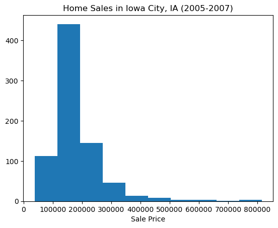

```python
## Histogram
plt.hist(ic['sale.amount'])
plt.title('Home Sales in Iowa City, IA (2005-2007)')
plt.xlabel('Sale Price')
plt.show()
```

In JupyterLabs (and most other IDEs) the final command, `plt.show()`, is not actually needed to display the figure. However, it will supress any output related to the creation of a figure that is not the figure itself.

Templates for a couple of other useful graphics are shown below:

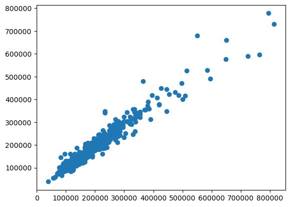

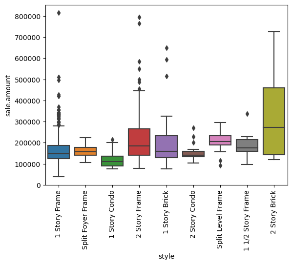

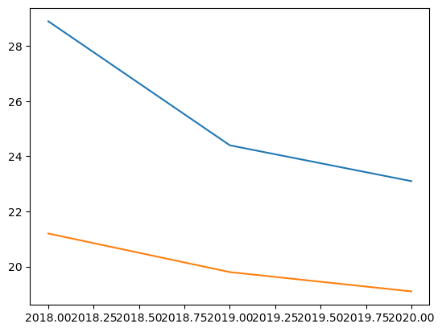

```python
## Scatterplot
plt.scatter(ic['sale.amount'], ic['assessed'])
plt.show()

## Boxplots (these are easier to create using another graphics library, 'seaborn')
import seaborn as sns
sns.boxplot(x=ic['style'], y=ic['sale.amount'])
plt.xticks(rotation=90)
plt.show()

## Line graph (the default of `plot`)
plt.plot(collegeAdm[collegeAdm['College'] == 'Grinnell']['Year'], collegeAdm[collegeAdm['College'] == 'Grinnell']['Adm_Rate'])
plt.plot(collegeAdm[collegeAdm['College'] == 'Carlton']['Year'], collegeAdm[collegeAdm['College'] == 'Carlton']['Adm_Rate'])
plt.show()
```

In these examples, note that `seaborn` and `matplotlib` are sometimes compatible with each other (we could use `plt.xticks()` on our `seaborn` boxplot).

#### Displaying Multiple Graphics

For many machine learning applications we'll want to look at several similar visualizations (ie: distributions of different predictors, different possible transformations, performance of different models, etc.) A grid containing several plots can be constructed using `plt.subplots()`:

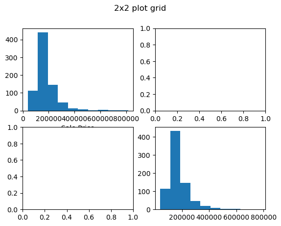

```python
## 2x2 grid of plots
fig, axs = plt.subplots(2,2)
fig.suptitle('2x2 plot grid')
axs[0,0].hist(ic['sale.amount'])
axs[0,0].set(xlabel='Sale Price')
axs[1,1].hist(ic['assessed'])
plt.show()
```

The first command might look a bit surprising, but Python allows functions to return multiple objects (`plt.subplots` returns two). We store these objects as `fig` and `axs`.

The object `fig` controls features of the entire grid, while `axs` allows you to control individual subfigures along either axis of the grid.

In general, I'd recommend using subplot grids for the display of final results. For data exploration purposes, `pandas` DataFrames have a few built-in graphics methods that are much easier than looping through and using subplots:

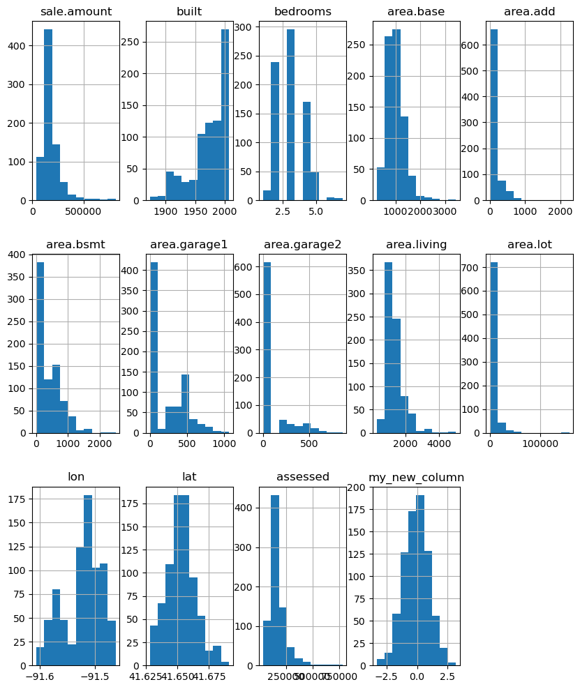

```python
## Histograms of all numeric variables
ic_num = ic.select_dtypes(include=['number'])
ic_num.hist(figsize=(10, 12), layout=(3,5))
plt.show()
```

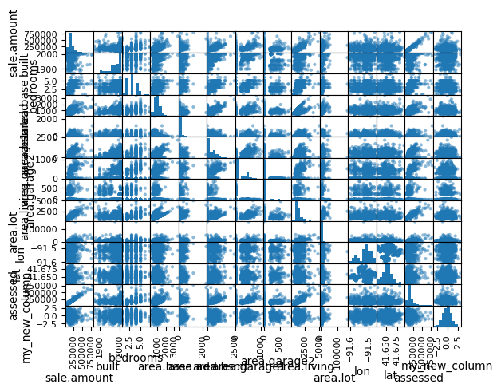

```python
## Scatterplot matrix of all pairing of numeric vars
from pandas.plotting import scatter_matrix
scatter_matrix(ic_num)
plt.show()
```

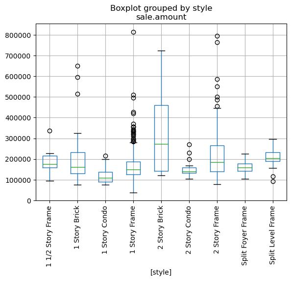

```python
## Boxplots (with groupings)
ic[['sale.amount','style']].boxplot(by='style')
plt.xticks(rotation=90)
plt.show()
```

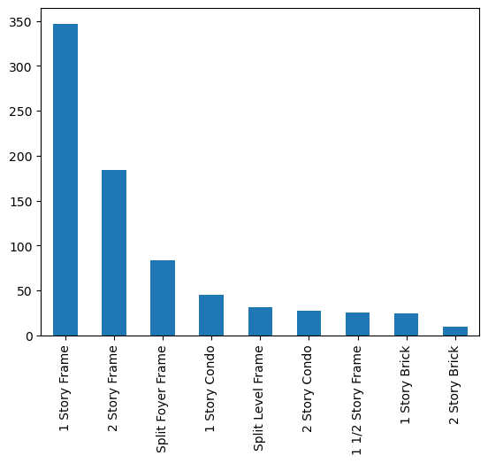

```python
## Bar chart for a categorical var (note that the data must be converted to counts first)
ic_style_counts = ic['style'].value_counts()
ic_style_counts.plot(kind='bar')
plt.show()
```

For additional examples and information on `pandas` graphics, you can use [this reference page](https://pandas.pydata.org/docs/user_guide/visualization.html#).

Finally, image data can be handled using the `skimage` library, which contains functions that will automatically read images into `numpy` arrays (and display appropriately formatted `numpy` arrays as images):

[figure not shown]

```
(238, 400, 4)
```

```python
from skimage import io
my_img = io.imread("https://www.iowacollegefoundation.org/_assets/image/schools/grinnell-college/grinnell-college.png")
io.imshow(my_img)
io.show()
my_img.shape
```

In future labs we'll occasionally apply machine learning methods to image data. So it's worthwhile knowing how to display an image that is stored as a `numpy` array.

#### Question #5

The code below reads a dataset containing 9-month salaries of faculty members at a large university (in 2008-09). You will use these data for this question.

- Part A - Set up a 2x2 grid of plots. Then, in the first plot of the first row, create a barchart that displays the average salary for male and female faculty. *Hint*: use `groupby`.
- Part B - In the second plot of the first row, create a scatterplot displaying the relationship between years of service and salary
- Part C - In the second row, create a histogram displaying the distribution of years of experience *for female faculty only* in one column of the subplot grid, and the same plot *for male faculty only* in the other column of the subplot grid.

```python
## Read data
profs = pd.read_csv("https://remiller1450.github.io/data/Salaries.csv")
```